# دسته بندی

#### ۲۲.افزایش تعداد دسته ها

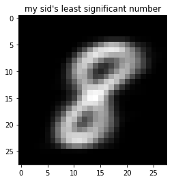

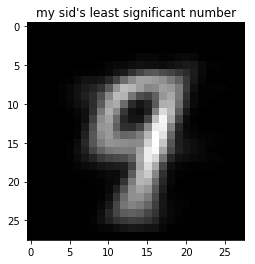

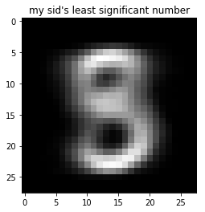

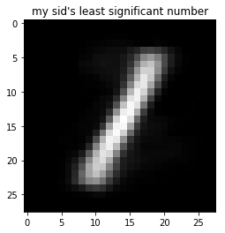

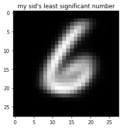

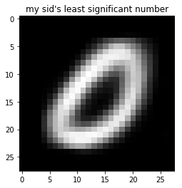

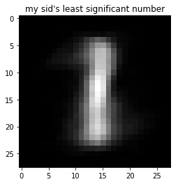

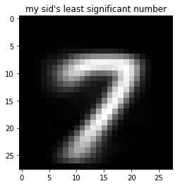

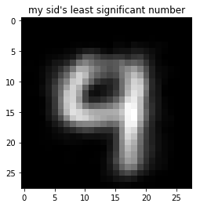

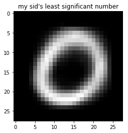

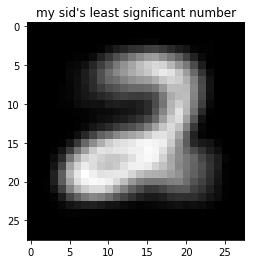

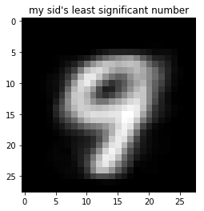

[3 more figures not shown]

```python
kmeans = KMeans(n_clusters=15, max_iter=300)

kmeans.fit(mnist)

centroids = kmeans.cluster_centers_

for i in range(0, 15):
        pixels = np.array(centroids[i], dtype='uint8')

        # Reshape the array into 28 x 28 array (2-dimensional array)
        pixels = pixels.reshape((28, 28))

        plt.title('my sid\'s least significant number')
        plt.imshow(pixels, cmap='gray')
        plt.show()
```

```python
index_labels = [8,9,3,1,6,0,1,7,4,0,2,9,5,3,6]
prediction_index = kmeans.predict(data_eval)
prediction = []
for i in prediction_index:
    prediction.append(index_labels[i])
prediction = np.array(prediction)
print(classification_report(label_eval, prediction))
print("Accuracy of test:", metrics.accuracy_score(label_eval, prediction))
```

```
              precision    recall  f1-score   support

           0       1.00      0.69      0.81        16
           1       0.61      1.00      0.76        25
           2       0.88      0.52      0.65        27
           3       0.29      0.73      0.42        15
           4       0.50      0.58      0.54        19
           5       0.62      0.42      0.50        12
           6       0.85      0.79      0.81        28
           7       1.00      0.14      0.25        21
           8       1.00      0.21      0.35        19
           9       0.27      0.47      0.34        17

    accuracy                           0.57       199
   macro avg       0.70      0.55      0.54       199
weighted avg       0.73      0.57      0.57       199

Accuracy of test: 0.5728643216080402
```

#### ۲۳.مقایسه عملکرد kmeans و knn

بنظر kmeans اگر برای منظور دسته بندی استفاده شود بهتر است. چرا که سریعا با مقایسه داده با مرکز هر دسته یعنی تعداد کمی نقطه می تواند کلاس داده را تعیین کند.

### جمع بندی انواع الگوریتم های دسته بندی

#### ۲۴.بهترین الگوریتم

جنگل تصادفی با دقت بالای نود درصد برای ارتفاع بهینه که از حدود ۱۵ تقریبا saturate می شود و ۳۵۰ تخمین زننده.

### کاهش ابعاد بردار ویژگی

#### ۲۷.توضیح

این الگوریتم سعی دارد که به رابطه بین مقادیر مختلف بردار های یک مجموعه پی ببرد، به جای اینکه با تعدادی از آن ها قصد پیشبینی مقادیری را داشته باشد. این روابط به وسیله محورهای بنیادی توصیف می شوند. که این محورها را با تعدادی عدد نمایش میدهد. این اعداد پراکندگی داده ها و مولفه ها هستند. پراکندگی جهت محور بنیادی را نشان میدهد. چرا برای کاهش ابعاد از این روش استفاده می شود؟ چون با اطلاعات موجود با حذف مولفه های کوچکتر و حفظ پراکندگی، ابعاد را کاهش میدهد. اهمیت این کار از آن جهت است که الگوریتم های مبتنی بر فاصله اقلیدسی در ابعاد بالا فواصل خوبی برای محاسبات نخواهند داشت.

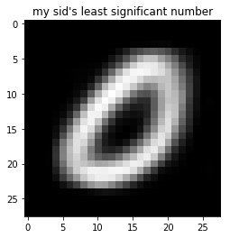

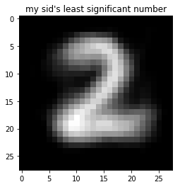

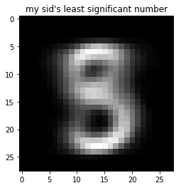

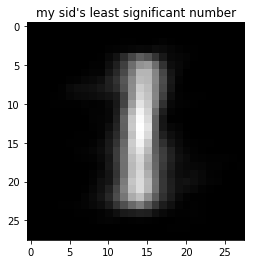

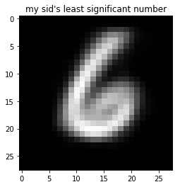

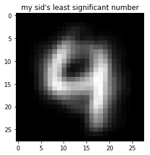

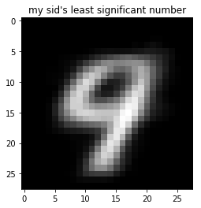

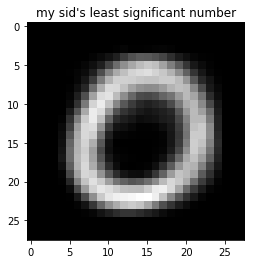

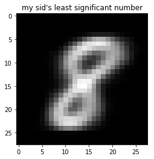

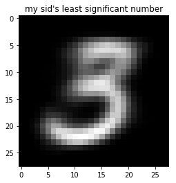

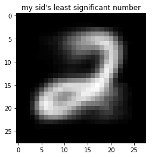

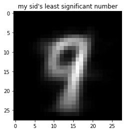

[3 more figures not shown]

```python
from sklearn.decomposition import PCA

pca = PCA(n_components=15).fit(mnist)
kmeans = KMeans(n_clusters=15, max_iter=300)

kmeans.fit(mnist)

centroids = kmeans.cluster_centers_

for i in range(0, 15):
        pixels = np.array(centroids[i], dtype='uint8')

        # Reshape the array into 28 x 28 array (2-dimensional array)
        pixels = pixels.reshape((28, 28))

        plt.title('my sid\'s least significant number')
        plt.imshow(pixels, cmap='gray')
        plt.show()
```

```python
index_labels = [0,2,3,1,6,4,9,0,8,3,2,9,5,7,1]
prediction_index = kmeans.predict(data_eval)
prediction = []
for i in prediction_index:
    prediction.append(index_labels[i])
prediction = np.array(prediction)
print(classification_report(label_eval, prediction))
print("Accuracy of test:", metrics.accuracy_score(label_eval, prediction))
```

```
              precision    recall  f1-score   support

           0       0.92      0.69      0.79        16
           1       0.68      1.00      0.81        25
           2       0.96      0.85      0.90        27
           3       0.33      0.73      0.46        15
           4       0.39      0.58      0.47        19
           5       0.56      0.42      0.48        12
           6       0.94      0.57      0.71        28
           7       1.00      0.19      0.32        21
           8       1.00      0.26      0.42        19
           9       0.30      0.53      0.38        17

    accuracy                           0.60       199
   macro avg       0.71      0.58      0.57       199
weighted avg       0.74      0.60      0.60       199

Accuracy of test: 0.6030150753768844
```